# Dynamic analysis

## Preamble

In this document, we perform the dynamic risk assessment. In particular, we investigate how the transient CRS dynamics and 30-year CRS burden change when we allow modest improvements in routine RCV coverage over time and introduce supplemental immunization activities (SIAs).

Relevant simulations must be performed in `model_simulators.Rmd` prior to running this R Markdown document.

## Installation of packages

Here are the packages required:

```r
library(tidyverse)
library(sf)
library(magrittr)
library(cowplot)
library(RColorBrewer)
library(lemon)
```

## Links to local data sets

Here we use the following links to local data:

```r
DATA_FOLDER <- file.path("..", "data")
PARAMETERS_FOLDER <- file.path("parameters")
POPULATION_DATA_FOLDER <- file.path(DATA_FOLDER, "population_data")
SPATIAL_POLYGONS_FOLDER <- file.path(DATA_FOLDER, "spatial_polygons")
VACCINATION_DATA_FOLDER <- file.path(DATA_FOLDER, "vaccination_data")

# derived data from `nigeria_data_organization_exploration.Rmd`
ng1_path <- file.path(SPATIAL_POLYGONS_FOLDER, "ng1.rds")
ng2_pop_path <- file.path(POPULATION_DATA_FOLDER, "ng2_pop.rds")

# local data
ng1_fertility_data_path <- file.path(POPULATION_DATA_FOLDER, "ng1_fertility_data.csv")
ng1_zone_mapping_path <- file.path(POPULATION_DATA_FOLDER, "ng1_zone_designations.xlsx")
ng1_mcv1_data_path <- file.path(VACCINATION_DATA_FOLDER, "ng1_mcv1_data.xlsx")
```

These are the paths we use for the simulation output.

```r
ALL_OUTPUT_FOLDER <- "~/Desktop/output/"
STATIC_SIMS_FOLDER <- file.path(ALL_OUTPUT_FOLDER, "static_risk_simulations", "raw_simulations")
DYNAMIC_SIMS_FOLDER <- file.path(ALL_OUTPUT_FOLDER, "dynamic_risk_simulations", "raw_simulations")
SUMMARY_DYNAMIC_SIMS_FOLDER <- file.path(ALL_OUTPUT_FOLDER, "dynamic_risk_simulations", "summary_simulations")
SUMMARY_STATIC_SIMS_FOLDER <- file.path(ALL_OUTPUT_FOLDER, "static_risk_simulations", "summary_simulations")
FIGURES_FOLDER <- file.path("figures", "dynamic_analysis")
```

Change these paths if you would like to run this on your local device.

## Data sets

Let’s read in the main data sets:

```r
ng2_pop <- readRDS(ng2_pop_path)
ng1_pop <- ng2_pop %>%
  group_by(state, gender, agegrp) %>%
  summarise(n=sum(n, na.rm=TRUE), .groups="keep") %>%
  spread(key="gender", value="n") %>%
  mutate(n=m+f) %>%
  ungroup()
ng1_zone_mapping <- readxl::read_excel(ng1_zone_mapping_path)
ng1 <- readRDS(ng1_path) %>%
  left_join(ng1_zone_mapping, by="state")
ng1_mcv1_data <- readxl::read_excel(ng1_mcv1_data_path)
ng1_cbr_data <- read.csv(ng1_fertility_data_path) %>%
  gather(key="agegrp", value="asfr", 2:ncol(.)) %>%
  mutate(agegrp=substr(gsub("X", "", agegrp), 1, 2)) %>%
  right_join(ng1_pop, by=c("state", "agegrp")) %>%
  mutate(asfr=ifelse(is.na(asfr), 0, asfr),
         births=asfr*f) %>%
  group_by(state) %>%
  summarise(cbr=sum(births)/sum(n)*1000, .groups="keep") %>%
  as.data.frame()
```

## Preliminary simulation output data management

We start by organizing the simulation output.

### CRS burden: simple dynamic analysis (improvements in routine coverage)

We start by computing the CRS incidence and birth time series for each state.

```r
states <- c(sort(unique(pull(ng2_pop, state))), "Nigeria")
scenarios <- c(0, 0.01, 0.025, 0.05, 0.1)
all_basic_scenarios_crs_incidence_list <- list()
for (this_state in states) {
  print(this_state)
  crs_incidence_list <- list()
  for (ii in seq_along(scenarios)) {
    # retrieve the simulation output for the desired state
    if (scenarios[ii]==0) {
      output_files <- list.files(path=STATIC_SIMS_FOLDER, pattern=paste(this_state, "tf30", "vac", sep="_"))
      num_files <- length(output_files)
      for (jj in 1:min(num_files, 100)) {
        output_files[[jj]] <- paste(this_state, "tf30", "vac", paste0("simNum", jj), sep="_")
      }
    } else {
      output_files <- list.files(path=DYNAMIC_SIMS_FOLDER,
                                 pattern=paste(this_state, "tf30", paste0("vacRate", scenarios[ii]*1000, "_"), sep="_"))
      num_files <- length(output_files)
      for (jj in 1:num_files) {
        output_files[[jj]] <- paste(this_state, "tf30", paste0("vacRate", scenarios[ii]*1000), paste0("simNum", jj), sep="_")
      }
    }

    # retrieve the crs incidence and births in each simulation
    params <- readRDS(file=file.path(PARAMETERS_FOLDER, this_state, "basic_parameters.rds"))
    state_crs_incidence_list <- list()
    pb = txtProgressBar(min = 0, max = length(output_files), initial = 0, style=3)
    for (jj in seq_along(output_files)) {
      if (scenarios[ii]==0) sim <- readRDS(file.path(STATIC_SIMS_FOLDER, output_files[[jj]]))
      else sim <- readRDS(file.path(DYNAMIC_SIMS_FOLDER, output_files[[jj]]))

      # compute crs incidence
      EP <- sim[, paste("EP", 1:params$num_stages, sep="")] %>% as.data.frame()
      sigma <- params$sigma
      c <- 0.65
      crs_incidence <- apply(EP, 1, function(x) sum(c*x*sigma))
      state_crs_incidence_list[[jj]] <- crs_incidence
      setTxtProgressBar(pb, jj)
    }
    close(pb)
    crs_incidence_list[[ii]] <- do.call(cbind, state_crs_incidence_list) %>%
      as.data.frame() %>%
      mutate(time=sim[, 1]) %>%
      select(time, dplyr::everything()) %>%
      setNames(c("time", paste("sim", seq_along(output_files), sep="")))
  }
  all_basic_scenarios_crs_incidence_list[[this_state]] <- crs_incidence_list
}
saveRDS(all_basic_scenarios_crs_incidence_list, file=file.path(SUMMARY_DYNAMIC_SIMS_FOLDER, "all_basic_scenarios_crs_incidence_list.rds"))
```

Let’s compute the 30-year CRS burden for each simulation in each state under each scenario.

```r
compute_crs_burden_distribution <- function(this_state, crs_incidence_list, births_list, scenarios) {
  state_crs_incidence_list <- crs_incidence_list[[this_state]]
  state_births <- births_list[[this_state]]

  # compute the long-term CRS burden in each simulation
  output_list <- list()
  for (jj in seq_along(scenarios)) {
    state_crs_incidence <- state_crs_incidence_list[[jj]]
    crs_burdens <- rep(NA, ncol(state_crs_incidence)-1)
    for (ii in 1:(ncol(state_crs_incidence)-1)) {
      crs_incidence <- state_crs_incidence[, 1+ii]
      births <- state_births[, 2]
      crs_burdens[ii] <- sum(crs_incidence)/sum(births)*10^5
    }
    output_list[[jj]] <- data.frame(scenario=scenarios[jj], state=this_state, crs_burden=crs_burdens, sim=seq_along(crs_burdens))
  }
  output <- do.call(rbind, output_list)
  return(output)
}
births_list <- readRDS(file.path(SUMMARY_STATIC_SIMS_FOLDER, "births_series_list.rds"))
states <- c(sort(unique(pull(ng2_pop, state))), "Nigeria")
scenarios <- c(0, 0.01, 0.025, 0.05, 0.1)
crs_burden_dist <- do.call(rbind, purrr::map(states, function(x)
  compute_crs_burden_distribution(x, crs_incidence_list=all_basic_scenarios_crs_incidence_list, births_list=births_list, scenarios=scenarios)))
saveRDS(crs_burden_dist, file=file.path(SUMMARY_DYNAMIC_SIMS_FOLDER, "simple_dynamic_crs_burden_dist.rds"))
```

Let’s also read in the simulations performed for each state at the median $R_0$.

```r
states <- c(sort(unique(pull(ng2_pop, state))), "Nigeria")
scenarios <- c(-1, 0, 0.01, 0.025, 0.05, 0.1)
median_r0_simNums <- readRDS(file.path(SUMMARY_STATIC_SIMS_FOLDER, "median_r0_simNums_optimization.rds"))
ng0_median_r0_simNum <- readRDS(file.path(SUMMARY_STATIC_SIMS_FOLDER, "ng0_r0_simNums_optimization.rds"))
median_r0_simNums <- c(median_r0_simNums, "Nigeria"=as.numeric(ng0_median_r0_simNum["median"]))
basic_scenarios_medR0_crs_incidence_list <- list()
for (this_state in states) {
  print(this_state)
  median_r0_simNum <- median_r0_simNums[this_state]
  crs_incidence_list <- list()
  for (ii in seq_along(scenarios)) {
    # retrieve the simulation output for the desired state
    if (scenarios[ii]==-1) {
      output_file <- file.path(STATIC_SIMS_FOLDER, paste0(this_state, "_tf30", "_noVac", "_simNum", median_r0_simNum))
    } else {
      output_file <- file.path(DYNAMIC_SIMS_FOLDER, paste0(this_state, "_tf30", "_vacRate", scenarios[ii]*1000, "_simNum", median_r0_simNum))
    }

    # retrieve the crs incidence and births in each simulation
    params <- readRDS(file=file.path(PARAMETERS_FOLDER, this_state, "basic_parameters.rds"))
    sim <- readRDS(output_file)

    # compute crs incidence
    EP <- sim[, paste("EP", 1:params$num_stages, sep="")] %>% as.data.frame()
    sigma <- params$sigma
    c <- 0.65
    crs_incidence <- apply(EP, 1, function(x) sum(c*x*sigma))
    crs_incidence_list[[ii]] <- crs_incidence %>%
      as.data.frame() %>%
      mutate(time=sim[, 1]) %>%
      select(time, dplyr::everything()) %>%
      setNames(c("time", paste0("s", ii)))
  }
  scenario_names <- c("baseline", 0, 0.01, 0.025, 0.05, 0.1)
  names(scenario_names) <- paste("s", 1:6, sep="")
  basic_scenarios_medR0_crs_incidence_list[[this_state]] <- purrr::reduce(crs_incidence_list, left_join, by="time") %>%
    gather(key="scenario", value="crs", 2:ncol(.)) %>%
    mutate(scenario=scenario_names[scenario],
           state=this_state, simNum=median_r0_simNum) %>%
    select(state, simNum, time, scenario, crs)
}
saveRDS(basic_scenarios_medR0_crs_incidence_list, file=file.path(SUMMARY_DYNAMIC_SIMS_FOLDER, "basic_scenarios_medR0_crs_incidence_list.rds"))
```

### CRS burden: advanced dynamic analysis (SIAs)

We start by computing the CRS incidence and birth time series for each state.

```r
states <- c(sort(unique(pull(ng2_pop, state))), "Nigeria")
scenarios <- c(0, 0.01, 0.025, 0.05, 0.1)
sia_types <- c("sia1", "sia2")
for (this_sia in sia_types) {
  all_advanced_scenarios_crs_incidence_list <- list()
  for (this_state in states) {
    print(this_state)
    crs_incidence_list <- list()
    for (ii in seq_along(scenarios)) {
      # retrieve the simulation output for the desired state
      output_files <- list.files(path=DYNAMIC_SIMS_FOLDER,
                                 pattern=paste(this_state, "tf30", this_sia, paste0("vacRate", scenarios[ii]*1000, "_"), sep="_"))
      num_files <- length(output_files)
      for (jj in 1:min(100, num_files)) {
        output_files[[jj]] <- paste(this_state, "tf30", this_sia, paste0("vacRate", scenarios[ii]*1000), paste0("simNum", jj), sep="_")
      }

      # retrieve the crs incidence and births in each simulation
      params <- readRDS(file=file.path(PARAMETERS_FOLDER, this_state, "basic_parameters.rds"))
      state_crs_incidence_list <- list()
      pb = txtProgressBar(min = 0, max = length(output_files), initial = 0, style=3)
      for (jj in seq_along(output_files)) {
        sim <- readRDS(file.path(DYNAMIC_SIMS_FOLDER, output_files[[jj]]))

        # compute crs incidence
        EP <- sim[, paste("EP", 1:params$num_stages, sep="")] %>% as.data.frame()
        sigma <- params$sigma
        c <- 0.65
        crs_incidence <- apply(EP, 1, function(x) sum(c*x*sigma))
        state_crs_incidence_list[[jj]] <- crs_incidence
        setTxtProgressBar(pb, jj)
      }
      close(pb)
      crs_incidence_list[[ii]] <- do.call(cbind, state_crs_incidence_list) %>%
        as.data.frame() %>%
        mutate(time=sim[, 1]) %>%
        select(time, dplyr::everything()) %>%
        setNames(c("time", paste("sim", seq_along(output_files), sep="")))
    }
    all_advanced_scenarios_crs_incidence_list[[this_state]] <- crs_incidence_list
  }
  saveRDS(all_advanced_scenarios_crs_incidence_list, file=file.path(SUMMARY_DYNAMIC_SIMS_FOLDER, paste0("all_advanced_scenarios_", this_sia, "_crs_incidence_list.rds")))
}
```

Let’s compute the 30-year CRS burden for each simulation in each state under each scenario.

```r
compute_crs_burden_distribution <- function(this_state, crs_incidence_list, births_list, scenarios) {
  state_crs_incidence_list <- crs_incidence_list[[this_state]]
  state_births <- births_list[[this_state]]

  # compute the long-term CRS burden in each simulation
  output_list <- list()
  for (jj in seq_along(scenarios)) {
    state_crs_incidence <- state_crs_incidence_list[[jj]]
    crs_burdens <- rep(NA, ncol(state_crs_incidence)-1)
    for (ii in 1:(ncol(state_crs_incidence)-1)) {
      crs_incidence <- state_crs_incidence[, 1+ii]
      births <- state_births[, 2]
      crs_burdens[ii] <- sum(crs_incidence)/sum(births)*10^5
    }
    output_list[[jj]] <- data.frame(scenario=scenarios[jj], state=this_state, crs_burden=crs_burdens, sim=seq_along(crs_burdens))
  }
  output <- do.call(rbind, output_list)
  return(output)
}
states <- c(sort(unique(pull(ng2_pop, state))), "Nigeria")
scenarios <- c(0, 0.01, 0.025, 0.05, 0.1)
for (this_sia in c("sia1", "sia2")) {
  all_advanced_scenarios_crs_incidence_list <- readRDS(file.path(SUMMARY_DYNAMIC_SIMS_FOLDER, paste0("all_advanced_scenarios_", this_sia, "_crs_incidence_list.rds")))
  advanced_dynamic_crs_burden_dist <- do.call(rbind, purrr::map(states, function(x)
    compute_crs_burden_distribution(x,
                                    crs_incidence_list=all_advanced_scenarios_crs_incidence_list,
                                    births_list=births_list,
                                    scenarios=scenarios))) %>%
    as.data.frame() %>%
    mutate(sia=this_sia)
  saveRDS(advanced_dynamic_crs_burden_dist, file.path(SUMMARY_DYNAMIC_SIMS_FOLDER, paste0("advanced_dynamic_", this_sia, "_crs_burden_dist.rds")))
}
```

Let’s also read in the simulations performed for each state at the median $R_0$.

```r
states <- c(sort(unique(pull(ng2_pop, state))), "Nigeria")
scenarios <- c(-1, 0, 0.01, 0.025, 0.05, 0.1)
median_r0_simNums <- readRDS(file.path(SUMMARY_STATIC_SIMS_FOLDER, "median_r0_simNums_optimization.rds"))
ng0_median_r0_simNum <- readRDS(file.path(SUMMARY_STATIC_SIMS_FOLDER, "ng0_r0_simNums_optimization.rds"))
median_r0_simNums <- c(median_r0_simNums, "Nigeria"=as.numeric(ng0_median_r0_simNum["median"]))
for (this_sia in c("sia1", "sia2")) {
  advanced_scenarios_medR0_crs_incidence_list <- list()
  for (this_state in states) {
    print(this_state)
    median_r0_simNum <- median_r0_simNums[this_state]
    crs_incidence_list <- list()
    for (ii in seq_along(scenarios)) {
      # retrieve the simulation output for the desired state
      if (scenarios[ii]==-1) {
        output_file <- file.path(STATIC_SIMS_FOLDER, paste0(this_state, "_tf30", "_noVac", "_simNum", median_r0_simNum))
      } else {
        output_file <- file.path(DYNAMIC_SIMS_FOLDER, paste0(this_state, "_tf30_", this_sia, "_vacRate", scenarios[ii]*1000, "_simNum", median_r0_simNum))
      }

      # retrieve the crs incidence and births in each simulation
      params <- readRDS(file=file.path(PARAMETERS_FOLDER, this_state, "basic_parameters.rds"))
      sim <- readRDS(output_file)

      # compute crs incidence
      EP <- sim[, paste("EP", 1:params$num_stages, sep="")] %>% as.data.frame()
      sigma <- params$sigma
      c <- 0.65
      crs_incidence <- apply(EP, 1, function(x) sum(c*x*sigma))
      crs_incidence_list[[ii]] <- crs_incidence %>%
        as.data.frame() %>%
        mutate(time=sim[, 1]) %>%
        select(time, dplyr::everything()) %>%
        setNames(c("time", paste0("s", ii)))
    }
    scenario_names <- c("baseline", 0, 0.01, 0.025, 0.05, 0.1)
    names(scenario_names) <- paste("s", 1:6, sep="")
    advanced_scenarios_medR0_crs_incidence_list[[this_state]] <- purrr::reduce(crs_incidence_list, left_join, by="time") %>%
      gather(key="scenario", value="crs", 2:ncol(.)) %>%
      mutate(scenario=scenario_names[scenario],
             state=this_state, simNum=median_r0_simNum,
             sia=this_sia) %>%
      select(sia, state, simNum, time, scenario, crs)
  }
  saveRDS(advanced_scenarios_medR0_crs_incidence_list, file=file.path(SUMMARY_DYNAMIC_SIMS_FOLDER,
                                                                   paste0("advanced_scenarios_", this_sia, "_medR0_crs_incidence_list.rds")))
}
```

## Simulation datasets

Here, we read in the organized simulation output data.

### CRS burden: baseline analysis (without SIAs and improvement over time)

```r
baseline_crs_incidence_list <- readRDS(file.path(SUMMARY_STATIC_SIMS_FOLDER, "crs_incidence_series_list.rds"))
baseline_crs_burden_dist <- readRDS(file.path(SUMMARY_STATIC_SIMS_FOLDER, "crs_burden_dist.rds"))
births_list <- readRDS(file.path(SUMMARY_STATIC_SIMS_FOLDER, "births_series_list.rds"))
```

### CRS burden: simple dynamic analysis (improvements in routine coverage)

```r
all_basic_scenarios_crs_incidence_list <- readRDS(file.path(SUMMARY_DYNAMIC_SIMS_FOLDER, "all_basic_scenarios_crs_incidence_list.rds"))
simple_dynamic_crs_burden_dist <- readRDS(file.path(SUMMARY_DYNAMIC_SIMS_FOLDER, "simple_dynamic_crs_burden_dist.rds"))
basic_scenarios_medR0_crs_incidence_list <- readRDS(file.path(SUMMARY_DYNAMIC_SIMS_FOLDER, "basic_scenarios_medR0_crs_incidence_list.rds"))
```

### CRS burden: advanced dynamic analysis (SIAs)

```r
all_advanced_scenarios_sia1_crs_incidence_list <- readRDS(file.path(SUMMARY_DYNAMIC_SIMS_FOLDER, "all_advanced_scenarios_sia1_crs_incidence_list.rds"))
advanced_dynamic_sia1_crs_burden_dist <- readRDS(file.path(SUMMARY_DYNAMIC_SIMS_FOLDER, "advanced_dynamic_sia1_crs_burden_dist.rds"))
advanced_scenarios_sia1_medR0_crs_incidence_list <- readRDS(file.path(SUMMARY_DYNAMIC_SIMS_FOLDER, "advanced_scenarios_sia1_medR0_crs_incidence_list.rds"))
all_advanced_scenarios_sia2_crs_incidence_list <- readRDS(file.path(SUMMARY_DYNAMIC_SIMS_FOLDER, "all_advanced_scenarios_sia2_crs_incidence_list.rds"))
advanced_dynamic_sia2_crs_burden_dist <- readRDS(file.path(SUMMARY_DYNAMIC_SIMS_FOLDER, "advanced_dynamic_sia2_crs_burden_dist.rds"))
advanced_scenarios_sia2_medR0_crs_incidence_list <- readRDS(file.path(SUMMARY_DYNAMIC_SIMS_FOLDER, "advanced_scenarios_sia2_medR0_crs_incidence_list.rds"))
```

## CRS burden: simple dynamic analysis (improvements in routine coverage)

In this section, we focus on simple dynamic analysis looking at how modest increases in routine rubella vaccination coverage over time diminishes the risk of RCV introduction even at coverage levels that are expected to increase CRS burden in the long run.

### Yearly CRS incidence

Here, we look at the mean time series of CRS incidence in each state to get an idea of the possible temporal dynamics.

```r
# It takes the state name and returns a time series of the yearly CRS burden with uncertainty bars.
plot_yearly_crs_dynamics <- function(this_state, crs_incidence_list, births_list, scenarios,
                                     baseline_crs_incidence_list, baseline_births_list) {
  scenarios <- c(-1, scenarios)
  state_crs_incidence_list <- crs_incidence_list[[this_state]]
  state_births <- births_list[[this_state]]
  baseline_state_crs_incidence <- baseline_crs_incidence_list[[this_state]]
  baseline_state_births <- baseline_births_list[[this_state]]
  state_crs_incidence_list <- c(list(baseline_state_crs_incidence), state_crs_incidence_list)

  # compute the yearly crs incidence (per 100,000 live births) in each simulation
  yearly_incidence_summary_list <- list()
  for (this_scenario in seq_along(scenarios)) {
    state_crs_incidence <- state_crs_incidence_list[[this_scenario]]

    yearly_incidence_list <- list()
    yearly_incidence <- rep(0, floor(nrow(state_crs_incidence)/365))
    for (ii in 1:(ncol(state_crs_incidence)-1)) {
      crs_incidence <- state_crs_incidence[, 1+ii]
      if (this_scenario==1) births <- baseline_state_births[, 2]
      else births <- state_births[, 2]
      for (jj in seq(1, length(crs_incidence)-1, 365)) {
        yearly_incidence[floor(jj/365)+1] <- sum(crs_incidence[jj:(jj+364)])/sum(births[jj:(jj+364)])*10^5
      }
      yearly_incidence_list[[ii]] <- yearly_incidence
    }
    state_yearly_incidence <- do.call(cbind, yearly_incidence_list)
    state_yearly_incidence_summary <- apply(state_yearly_incidence, 1, function(x)
      c(median(x), mean(x), sd(x), quantile(x, c(0.025, 0.975)))) %>%
      t() %>%
      as.data.frame() %>%
      mutate(scenario=this_scenario, year=seq(1, floor(nrow(state_crs_incidence)/365), 1)) %>%
      select(scenario, year, dplyr::everything()) %>%
      setNames(c("scenario", "year", "median", "mean", "sd", "l95", "u95"))
    yearly_incidence_summary_list[[this_scenario]] <- state_yearly_incidence_summary
  }
  yearly_incidence_summary <- do.call(rbind, yearly_incidence_summary_list) %>%
    mutate(scenario=factor(scenario, (-1):6))

  p <- ggplot(yearly_incidence_summary) +
    geom_line(mapping=aes(x=year, y=mean, color=scenario), size=1) +
    geom_point(mapping=aes(x=year, y=mean, color=scenario), size=1) +
    labs(x="Year", y="CRS cases/\n100,000 live births", title=this_state) +
    scale_x_continuous(breaks=seq(0, 40, 5)) +
    scale_color_manual(values=brewer.pal(length(scenarios), "Dark2"), labels=c("No vaccination", paste0(scenarios[-1]*100, "%"))) +
    theme_bw() +
    theme(panel.grid.major=element_blank(), panel.grid.minor=element_blank(),
          panel.background=element_blank(), panel.border=element_blank(),
          axis.line = element_line(colour = "black")) +
    theme(axis.text = element_text(size=12), axis.title = element_text(size=14))
  return(p)
}
```

Here, we plot the yearly CRS dynamics at the median $R_0$ for the states.

```r
# It takes the state name and returns a time series of the yearly CRS burden with uncertainty bars.
plot_yearly_crs_dynamics <- function(these_states, state_highlights, crs_incidence_list, births_list, scenarios, file_name, legend=TRUE, scale_factor) {
  state_yearly_incidence_list <- list()
  for (this_state in these_states) {
    state_crs_incidence <- crs_incidence_list[[this_state]]
    state_births <- births_list[[this_state]]

    # compute the yearly crs incidence (per 100,000 live births) in each simulation
    yearly_incidence_list <- list()
    for (this_scenario in scenarios) {
      crs_incidence <- state_crs_incidence %>%
        filter(scenario==this_scenario) %>%
        arrange(-desc(time)) %>%
        pull(crs)
      yearly_incidence <- rep(0, floor(length(crs_incidence)/365))
      births <- state_births[, 2]
      for (jj in seq(1, length(crs_incidence)-1, 365)) {
        yearly_incidence[floor(jj/365)+1] <- sum(crs_incidence[jj:(jj+364)])/sum(births[jj:(jj+364)])*10^5
      }
      yearly_incidence_list[[which(this_scenario==scenarios)]] <- yearly_incidence
    }
    state_yearly_incidence_list[[this_state]] <- do.call(cbind, yearly_incidence_list) %>%
      as.data.frame() %>%
      setNames(scenarios) %>%
      mutate(year=seq(1, floor(length(crs_incidence)/365), 1)) %>%
      select(year, dplyr::everything()) %>%
      gather(key="scenario", value="crs", 2:ncol(.)) %>%
      mutate(state=this_state,
             color=ifelse(scenario==state_highlights[which(this_state==these_states)],
                          "red", "grey"))
  }
  state_yearly_incidence <- do.call(rbind, state_yearly_incidence_list) %>%
    as.data.frame() %>%
    mutate(scenario=factor(scenario, scenarios),
           state=factor(state, levels=these_states)) %>%
    mutate(color=ifelse(scenario=="baseline", "black", color))

  p <- ggplot(state_yearly_incidence) +
    geom_line(mapping=aes(x=year, y=crs, color=color, group=scenario)) +
    geom_point(mapping=aes(x=year, y=crs, shape=scenario), size=0.5) +
    labs(x="Year", y="CRS cases/100,000 live births") +
    scale_x_continuous(breaks=seq(0, 30, 5), expand=c(0, 0)) +
    scale_color_manual(breaks=c("red", "black", "grey"),
                       values=c("red", "black", "lightgrey"), guide="none") +
    scale_shape_manual(values=c(15, 16, 17, 18, 8, 3),
                       labels=c("No vaccination",
                                "Routine only",
                                "Routine + 1% increase",
                                "Routine + 2.5% increase",
                                "Routine + 5% increase",
                                "Routine + 10% increase"),
                       guide=guide_legend(override.aes = list(size=2.5))) +
    theme_bw() +
    theme(panel.grid.major=element_blank(), panel.grid.minor=element_blank(),
          panel.background=element_blank(), panel.border=element_blank(),
          axis.line = element_line(colour = "black")) +
    theme(legend.position="bottom", legend.title=element_blank(),
          legend.text=element_text(size=8), legend.key.size=unit(0.3, "cm")) +
    theme(axis.text = element_text(size=8, color="black"), axis.title.y = element_text(size=8, color="black"),
          axis.title.x=element_blank(), strip.text=element_text(size=8, color="black"),
          strip.background=element_blank()) +
    facet_rep_wrap(~state, ncol=2, scales="free_y")

  if (!legend) p <- p + theme(legend.position="none")
  pdf(file=file.path(FIGURES_FOLDER, file_name), w=8, h=11*scale_factor)
  print(p)
  a <- dev.off()
  return(p)
}
```

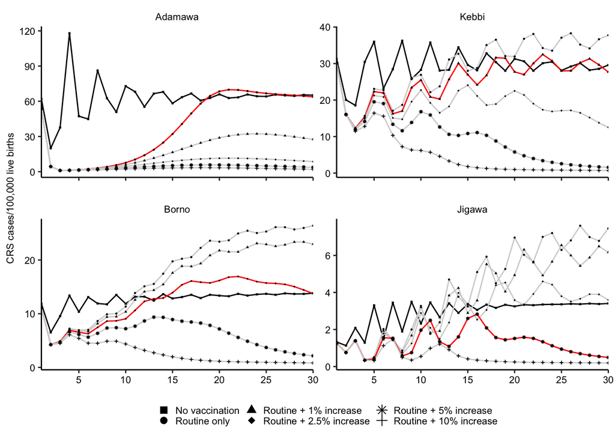

```r
# selected states
selected_yearly_crs_dynamics <- plot_yearly_crs_dynamics(these_states=c("Adamawa", "Kebbi", "Borno", "Jigawa"),
                                                         state_highlights=as.character(c(0, 0.01, 0.025, 0.05)),
                                                         crs_incidence_list=basic_scenarios_medR0_crs_incidence_list,
                                                         births_list=births_list,
                                                         scenarios=c("baseline", 0, 0.01, 0.025, 0.05, 0.1),
                                                         file_name="yearly_crs_incidence_timeseries_pub.pdf",
                                                         scale_factor=0.3)
selected_yearly_crs_dynamics
```

```r
# all states
states <- c(unique(pull(ng2_pop, state)), "Nigeria")
state_highlights <- simple_dynamic_crs_burden_dist %>%
  left_join(rename(baseline_crs_burden_dist, baseline_crs_burden=crs_burden),
            by=c("state", "sim")) %>%
  group_by(scenario, state) %>%
  summarise(mean_relative_burden=mean(crs_burden/baseline_crs_burden), .groups="keep") %>%
  ungroup() %>% group_by(state) %>%
  mutate(state=factor(state, levels=states)) %>%
  arrange(-desc(state), -desc(scenario)) %>%
  mutate(is_min_scenario=(scenario==scenario[min(which(mean_relative_burden<1))])) %>%
  filter(is_min_scenario) %>%
  pull(scenario)

plots_per_page <- 16
groupings <- split(seq_along(states), ceiling(seq_along(states)/plots_per_page))
scale_factors <- unlist(lapply(groupings, length))/plots_per_page*0.9
scale_factors[length(groupings)] <- scale_factors[length(groupings)] + 0.075
for (ii in seq_along(groupings)) {
  all_yearly_crs_dynamics <- plot_yearly_crs_dynamics(these_states=states[groupings[[ii]]],
                                                      state_highlights=as.character(state_highlights)[groupings[[ii]]],
                                                      crs_incidence_list=basic_scenarios_medR0_crs_incidence_list,
                                                      births_list=births_list,
                                                      legend=(ii==length(groupings)),
                                                      scenarios=c("baseline", 0, 0.01, 0.025, 0.05, 0.1),
                                                      file_name=paste0("yearly_crs_incidence_timeseries_group", ii, ".pdf"),
                                                      scale_factor=scale_factors[ii])
}
```

### Change in 30-year CRS burden

First, let’s have a look at how 30-year CRS burden changes in each state following the introduction of RCV vaccination under different rates of improvement in routine coverage over time.

We will start by showing whether there is an expected increase or decrease relative to the non-introduction scenario.

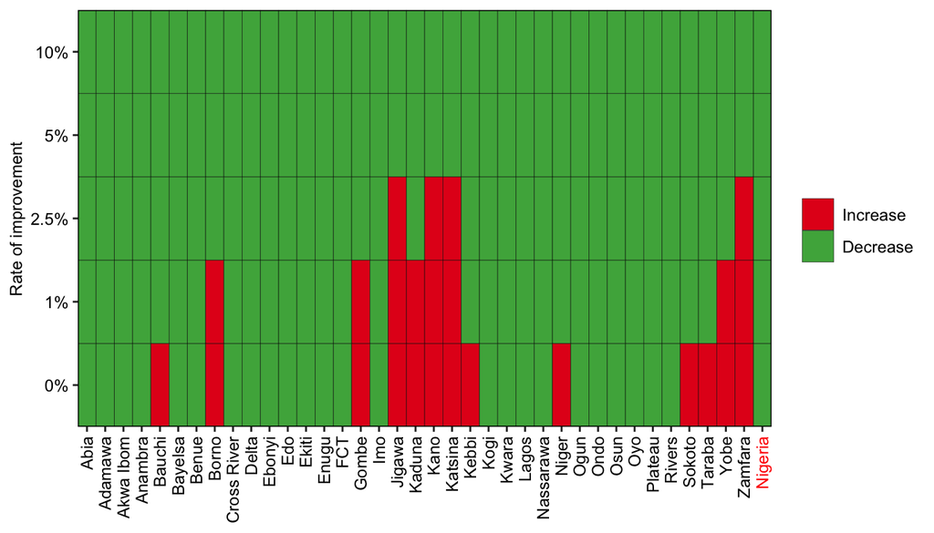

```r
plot_mean_crs_burden_binary_change_heatmap <- function(dynamic_crs_burden_dist, baseline_crs_burden_dist,
                                                       scenarios, file_name) {
  crs_burden_summary <- dynamic_crs_burden_dist %>%
    left_join(rename(baseline_crs_burden_dist, baseline_crs_burden=crs_burden),
                     by=c("state", "sim")) %>%
    mutate(change_crs_burden=crs_burden-baseline_crs_burden) %>%
    group_by(scenario, state) %>%
    summarise(mean_change_crs_burden=mean(change_crs_burden), .groups="keep") %>%
    mutate(binary_change=ifelse(mean_change_crs_burden>0, "increase", "decrease")) %>%
    mutate(scenario=factor(scenario, levels=scenarios)) %>%
    mutate(state=ifelse(state=="Federal Capital Territory", "FCT", state))
  state_order <- sort(unique(pull(crs_burden_summary, state)))
  state_order <- c(state_order[which(state_order!="Nigeria")], "Nigeria")
  crs_burden_summary %<>% mutate(state=factor(state, levels=state_order))

  axis_text_colors <- c(rep("black", length(state_order)-1), "red")

  mean_crs_burden_binary_change_heatmap <- ggplot(data=crs_burden_summary) +
    geom_tile(mapping=aes(x=state, y=scenario, fill=binary_change, color=binary_change), color="black") +
    labs(y="Rate of improvement", fill="") +
    scale_y_discrete(labels=paste0(round(scenarios*100, 1), "%"), expand=c(0, 0)) +
    scale_x_discrete(drop=FALSE, expand=c(0, 0)) +
    scale_fill_manual(breaks=c("increase", "decrease"), values=brewer.pal(9, "Set1")[c(1, 3)], labels=c("Increase", "Decrease")) +
        theme(axis.text.x=element_text(angle=90, size=9, hjust=1, vjust=0.5, color=axis_text_colors), axis.text=element_text(size=9, color="black"),
          axis.title.x=element_blank(),
          axis.title.y=element_text(size=9, color="black"),
          legend.position="right", legend.text=element_text(size=9, color="black"), legend.title=element_text(size=9, color="black")) +
    theme(panel.background=element_blank(), panel.grid=element_blank(), panel.border=element_rect(color="black", fill=NA))

  return(mean_crs_burden_binary_change_heatmap)
}
mean_crs_burden_binary_change_heatmap <- plot_mean_crs_burden_binary_change_heatmap(dynamic_crs_burden_dist=simple_dynamic_crs_burden_dist,
                                                                                    baseline_crs_burden_dist=baseline_crs_burden_dist,
                                                                                    scenarios=scenarios,
                                                                                    file_name="mean_crs_burden_binary_change_heatmap.pdf")
mean_crs_burden_binary_change_heatmap
```

Let’s have a look at how CRS burden is expected to quantitatively change.

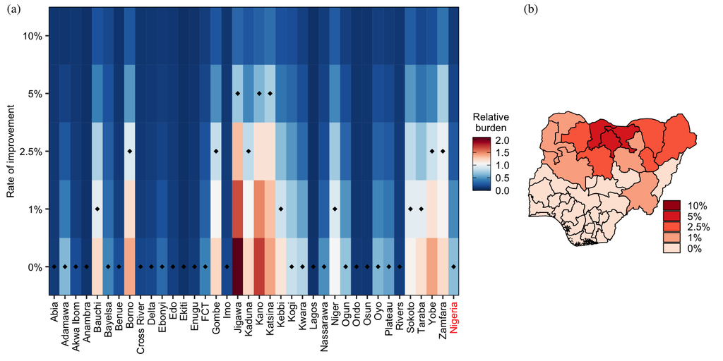

```r
plot_mean_crs_burden_change_heatmap <- function(ng1_polygons=ng1, dynamic_crs_burden_dist, baseline_crs_burden_dist, scenarios, file_name) {
  crs_burden_summary <- dynamic_crs_burden_dist %>%
    left_join(rename(baseline_crs_burden_dist, baseline_crs_burden=crs_burden),
                     by=c("state", "sim")) %>%
    mutate(change_crs_burden=crs_burden-baseline_crs_burden) %>%
    group_by(scenario, state) %>%
    summarise(mean_percent_change_crs_burden=mean(change_crs_burden/baseline_crs_burden)*100,
              mean_relative_burden=mean(crs_burden/baseline_crs_burden), .groups="keep") %>%
    mutate(scenario=factor(scenario, levels=scenarios)) %>%
    ungroup() %>% group_by(state) %>%
    arrange(-desc(state), -desc(scenario)) %>%
    mutate(is_min_scenario=(scenario==scenario[min(which(mean_relative_burden<1))])) %>%
    mutate(state=ifelse(state=="Federal Capital Territory", "FCT", state))
  state_order <- sort(unique(pull(crs_burden_summary, state)))
  state_order <- c(state_order[which(state_order!="Nigeria")], "Nigeria")
  crs_burden_summary %<>% mutate(state=factor(state, levels=state_order))

  # heat map
  axis_text_colors <- c(rep("black", length(state_order)-1), "red")
  mean_crs_burden_change_heatmap <- ggplot() +
    geom_tile(data=crs_burden_summary,
              mapping=aes(x=state, y=scenario, fill=mean_relative_burden, color=mean_relative_burden)) +
    geom_point(data=filter(crs_burden_summary, is_min_scenario),
               mapping=aes(x=state, y=scenario), shape=18) +
    scale_fill_gradientn(colours=rev(brewer.pal(11, "RdBu")), breaks=seq(0, 2, 0.5),
                         limits=c(0, 2.1), name="Relative\nburden") +
    scale_color_gradientn(colours=rev(brewer.pal(11, "RdBu")), breaks=seq(0, 2, 0.5),
                          limits=c(0, 2.1), guide="none") +
    labs(y="Rate of improvement", fill="Relative\nburden") +
    scale_y_discrete(labels=paste0(round(scenarios*100, 1), "%"), expand=c(0, 0)) +
    scale_x_discrete(drop=FALSE, expand=c(0, 0)) +
    guides(fill=guide_colorbar(title.position="top", title.hjust=0.5,
                             ticks.colour="black", frame.colour="black")) +
    theme(axis.text.x=element_text(angle=90, size=8, hjust=1, vjust=0.5, color=axis_text_colors), axis.text=element_text(size=8, color="black"),
          axis.title.x=element_blank(),
          axis.title.y=element_text(size=8, color="black"),
          legend.position="right", legend.text=element_text(size=8, color="black"), legend.title=element_text(size=8, color="black"),
          legend.key.size=unit(0.3, "cm"), legend.key.width=unit(0.5, "cm"), legend.margin=unit(c(0, 0, 0, 0), "cm")) +
    theme(panel.background=element_blank(), panel.grid=element_blank(), panel.border=element_rect(color="black", fill=NA))

  # geographical map
  ng1_polygons %<>% mutate(state=ifelse(state=="Federal Capital Territory", "FCT", state))
  min_scenario_map_data <- crs_burden_summary %>%
    ungroup() %>%
    filter(is_min_scenario, state!="Nigeria") %>%
    right_join(ng1_polygons, by="state")

  color_scale <- rev(brewer.pal(5, "RdYlBu"))
  color_scale <- brewer.pal(5, "Reds")
  min_scenario_map <- ggplot(data=min_scenario_map_data) +
    geom_sf(mapping=aes(geometry=geometry, fill=scenario), color="black", size=0.3) +
    scale_fill_manual(breaks=rev(c(0, 0.01, 0.025, 0.05, 0.10)), values=rev(color_scale),
                      labels=rev(paste0(round(scenarios*100, 1), "%")), drop=FALSE) +
    theme_bw() +
    guides(fill=guide_legend(title.position="top", title.hjust=0.5,
                             ticks.colour="black", frame.colour="black")) +
    theme(panel.grid.major=element_blank(), panel.grid.minor=element_blank(),
          panel.background=element_blank(), panel.border=element_blank(),
          axis.line=element_blank(), axis.ticks=element_blank(), axis.text=element_blank(),
          axis.title=element_blank()) +
    theme(legend.position=c(0.9, 0.2), legend.key.size=unit(0.3, "cm"), legend.key.width=unit(0.5, "cm"),
          legend.text=element_text(size=8), legend.title=element_blank(),
          legend.box.background=element_blank(), legend.background=element_blank()) +
    theme(plot.margin=unit(c(0, 0.5, 0, 0), "cm"))

  pAB <- cowplot::plot_grid(mean_crs_burden_change_heatmap, min_scenario_map, nrow=1, rel_widths=c(1, 0.4),
                            labels=c("(a)", "(b)"), label_size=10, label_fontface="plain", label_fontfamily="serif")
  return(pAB)
}
mean_crs_burden_change_heatmap <- plot_mean_crs_burden_change_heatmap(dynamic_crs_burden_dist=simple_dynamic_crs_burden_dist,
                                                                      baseline_crs_burden_dist=baseline_crs_burden_dist,
                                                                      scenarios=c(0, 0.01, 0.025, 0.05, 0.1),
                                                                      file_name="mean_crs_burden_change_heatmap.pdf")
mean_crs_burden_change_heatmap
```

Let’s combine a couple of the plots…

```r
mean_crs_burden_change_heatmap <- plot_mean_crs_burden_change_heatmap(dynamic_crs_burden_dist=simple_dynamic_crs_burden_dist,
                                                                      baseline_crs_burden_dist=baseline_crs_burden_dist,
                                                                      scenarios=c(0, 0.01, 0.025, 0.05, 0.1),
                                                                      file_name="mean_crs_burden_change_heatmap.pdf")
selected_yearly_crs_dynamics <- plot_yearly_crs_dynamics(these_states=c("Adamawa", "Kebbi", "Borno", "Jigawa"),
                                                         state_highlights=as.character(c(0, 0.01, 0.025, 0.05)),
                                                         crs_incidence_list=basic_scenarios_medR0_crs_incidence_list,
                                                         births_list=births_list,
                                                         scenarios=c("baseline", 0, 0.01, 0.025, 0.05, 0.1),
                                                         file_name="yearly_crs_incidence_timeseries_pub.pdf",
                                                         scale_factor=0.3)
pAB <- cowplot::plot_grid(mean_crs_burden_change_heatmap,
                          selected_yearly_crs_dynamics,
                          labels=c("", "(c)"), label_size=10, label_fontface="plain", label_fontfamily="serif",
                          rel_heights=c(0.7, 1),
                          ncol=1)
scale_factor <- 0.45
pdf(file=file.path(FIGURES_FOLDER, "effect_improvements_in_coverage.pdf"), w=8, h=11*scale_factor)
print(pAB)
a <- dev.off()
```

### Relative temporal dynamics

Let’s start by computing the yearly CRS incidence in each scenario for each state.

```r
# compute the yearly crs incidence (per 100,000 live births) in each simulation
scenarios <- c("baseline", 0, 0.01, 0.025, 0.05, 0.1)
states <- c(unique(pull(ng2_pop, state)), "Nigeria")

yearly_incidence_summary_list <- list()
for (this_state in states) {
  state_crs_incidence_list <- all_basic_scenarios_crs_incidence_list[[this_state]]
  baseline_state_crs_incidence <- baseline_crs_incidence_list[[this_state]]
  state_births <- births_list[[this_state]]
  state_crs_incidence_list <- c(list(baseline_state_crs_incidence), state_crs_incidence_list)

  state_yearly_incidence_summary_list <- list()
  for (this_scenario in seq_along(scenarios)) {
    state_crs_incidence <- state_crs_incidence_list[[this_scenario]]

    yearly_incidence_list <- list()
    yearly_incidence <- rep(0, floor(nrow(state_crs_incidence)/365))
    for (ii in 1:(ncol(state_crs_incidence)-1)) {
      crs_incidence <- state_crs_incidence[, 1+ii]
      births <- state_births[, 2]
      for (jj in seq(1, length(crs_incidence)-1, 365)) {
        yearly_incidence[floor(jj/365)+1] <- sum(crs_incidence[jj:(jj+364)])/sum(births[jj:(jj+364)])*10^5
      }
      yearly_incidence_list[[ii]] <- yearly_incidence
    }
    state_yearly_incidence <- do.call(cbind, yearly_incidence_list) %>%
      as.data.frame() %>%
      setNames(1:ncol(.)) %>%
      mutate(year=1:nrow(.)) %>%
      dplyr::select(year, dplyr::everything()) %>%
      gather(key="sim", value="crs_burden", 2:ncol(.)) %>%
      mutate(scenario=scenarios[this_scenario], state=this_state)
    state_yearly_incidence_summary_list[[this_scenario]] <- state_yearly_incidence
  }
  yearly_incidence_summary_list[[this_state]] <- do.call(rbind, state_yearly_incidence_summary_list)
}
yearly_incidence_summary <- do.call(rbind, yearly_incidence_summary_list)
row.names(yearly_incidence_summary) <- NULL
```

Let’s see the distribution in the relative yearly CRS incidence between the various vaccination scenarios and the non-vaccination scenario.

```r
plot_expected_yearly_incidence_distributions <- function(these_states, scenarios, yearly_incidence_summary,
                                                         dynamic_crs_burden_dist, baseline_crs_burden_dist,
                                                         file_name) {
  # long-term crs burden summary
  crs_burden_summary <- dynamic_crs_burden_dist %>%
    left_join(rename(baseline_crs_burden_dist, baseline_crs_burden=crs_burden),
                     by=c("state", "sim")) %>%
    mutate(change_crs_burden=crs_burden-baseline_crs_burden,
           relative_crs_burden=crs_burden/baseline_crs_burden,
           percent_change_crs_burden=(crs_burden-baseline_crs_burden)/baseline_crs_burden*100) %>%
    mutate(scenario=factor(scenario, levels=scenarios))

  # yearly incidence summmary
  baseline_yearly_incidence_summary <- yearly_incidence_summary %>%
    filter(scenario=="baseline") %>%
    select(-scenario) %>%
    rename(baseline_crs_burden=crs_burden)
  yearly_incidence_summary <- yearly_incidence_summary %>%
    filter(scenario!="baseline") %>%
    left_join(baseline_yearly_incidence_summary, by=c("year", "sim", "state")) %>%
    mutate(crs_burden_diff=crs_burden-baseline_crs_burden) %>%
    mutate(above=crs_burden_diff>0) %>%
    group_by(state, scenario, sim) %>%
    summarise(num_yrs_above=sum(above),
              rel_above=ifelse(num_yrs_above==0, NA, mean(crs_burden_diff[above])), .groups="keep") %>%
    as.data.frame() %>%
    mutate(scenario=factor(scenario, levels=scenarios),
           sim=as.numeric(sim))

  # combined simulation summary
  combined_crs_summary <- yearly_incidence_summary %>%
    left_join(crs_burden_summary, by=c("state", "scenario", "sim")) %>%
    filter(state %in% these_states) %>%
    select(state, scenario, sim, change_crs_burden, num_yrs_above, rel_above) %>%
    gather(key="metric", value="value", c("change_crs_burden", "num_yrs_above", "rel_above")) %>%
    mutate(metric=factor(metric, levels=c("change_crs_burden", "num_yrs_above", "rel_above"))) %>%
    group_by(state, scenario, metric) %>%
    summarise(median=median(value, na.rm=TRUE),
              l50=quantile(value, 0.25, na.rm=TRUE),
              u50=quantile(value, 0.75, na.rm=TRUE), .groups="keep")
  these_states[which(these_states=="Federal Capital Territory")] <- "FCT"
  combined_crs_summary %<>%
    mutate(state=ifelse(state=="Federal Capital Territory", "FCT", state)) %>%
    mutate(state=factor(state, levels=these_states))

  dummy_variable_for_axes <- data.frame(state=pull(combined_crs_summary, state)[1],
                                        scenario=pull(combined_crs_summary, scenario)[1],
                                        metric=c("change_crs_burden", "num_yrs_above", "rel_above"),
                                        median=c(0, 0, 0),
                                        l50=c(-100, 0, 0),
                                        u50=c(20, 30, 40))

  metric_label <- c(change_crs_burden="Change in 30-year CRS burden",
                    num_yrs_above="Number years above baseline",
                    rel_above="Relative yearly CRS incidence")
  p <- ggplot(data=combined_crs_summary) +
    geom_errorbar(dummy_variable_for_axes, mapping=aes(xmin=l50, xmax=u50, y=scenario), width=0, color="lightgrey") +
    geom_vline(xintercept=0, linetype="dashed", color="black") +
    geom_errorbar(mapping=aes(xmin=l50, xmax=u50, y=scenario), color="darkred", width=0, size=0.7) +
    geom_point(mapping=aes(x=median, y=scenario), color="black", shape=21, fill="white", size=1.2) +
    scale_y_discrete(labels=paste0(round(scenarios*100, 1), "%"), name="Rate of Improvement") +
    facet_grid(vars(state), vars(metric), scale="free", labeller=labeller(metric=metric_label)) +
    theme_bw() +
    theme(axis.title.x=element_blank()) +
    theme(panel.spacing.y = unit(0, "lines"), strip.background=element_rect(fill="white")) +
    theme(panel.grid=element_blank(), panel.grid.major.y=element_line(color="lightgrey"),
          axis.text=element_text(color="black", size=7),
          strip.text=element_text(color="black", size=8),
          axis.title=element_text(color="black", size=8))


  scale_factor <- length(these_states)/14*0.9
  pdf(file=file.path(FIGURES_FOLDER, file_name), w=8, h=11*scale_factor)
  print(p)
  a <- dev.off()
}
```

```r
all_states <- c(unique(pull(ng2_pop, state)), "Nigeria")
plots_per_page <- 14
groupings <- split(seq_along(all_states), ceiling(seq_along(all_states)/plots_per_page))
for (ii in seq_along(groupings)) {
  p <- plot_expected_yearly_incidence_distributions(these_states=all_states[groupings[[ii]]],
                                                    scenarios=c(0, 0.01, 0.025, 0.05, 0.1),
                                                    yearly_incidence_summary=yearly_incidence_summary,
                                                    dynamic_crs_burden_dist=simple_dynamic_crs_burden_dist,
                                                    baseline_crs_burden_dist=baseline_crs_burden_dist,
                                                    file_name=paste0("yearly_crs_incidence_dynamics_", "group", ii))
}
```

## CRS burden: advanced dynamic analysis

In this section, we focus on the dynamic analysis of simulations where routine infant vaccination coverage changes over time alongside regular supplemental immunization campaigns.

### Yearly CRS incidence (time-series)

Here, we plot the yearly CRS dynamics at the median $R_0$ for all states.

```r
# It takes the state name and returns a time series of the yearly CRS burden with uncertainty bars.
plot_yearly_crs_dynamics <- function(these_states, state_highlights, crs_incidence_list, births_list, scenarios, file_name, legend=TRUE, scale_factor) {
  state_yearly_incidence_list <- list()
  for (this_state in these_states) {
    state_crs_incidence <- crs_incidence_list[[this_state]]
    state_births <- births_list[[this_state]]

    # compute the yearly crs incidence (per 100,000 live births) in each simulation
    yearly_incidence_list <- list()
    for (this_scenario in scenarios) {
      crs_incidence <- state_crs_incidence %>%
        filter(scenario==this_scenario) %>%
        arrange(-desc(time)) %>%
        pull(crs)
      yearly_incidence <- rep(0, floor(length(crs_incidence)/365))
      births <- state_births[, 2]
      for (jj in seq(1, length(crs_incidence)-1, 365)) {
        yearly_incidence[floor(jj/365)+1] <- sum(crs_incidence[jj:(jj+364)])/sum(births[jj:(jj+364)])*10^5
      }
      yearly_incidence_list[[which(this_scenario==scenarios)]] <- yearly_incidence
    }
    state_yearly_incidence_list[[this_state]] <- do.call(cbind, yearly_incidence_list) %>%
      as.data.frame() %>%
      setNames(scenarios) %>%
      mutate(year=seq(1, floor(length(crs_incidence)/365), 1)) %>%
      select(year, dplyr::everything()) %>%
      gather(key="scenario", value="crs", 2:ncol(.)) %>%
      mutate(state=this_state,
             color=ifelse(scenario==state_highlights[which(this_state==these_states)],
                          "red", "grey"))
  }
  state_yearly_incidence <- do.call(rbind, state_yearly_incidence_list) %>%
    as.data.frame() %>%
    mutate(scenario=factor(scenario, scenarios),
           state=factor(state, levels=these_states)) %>%
    mutate(color=ifelse(scenario=="baseline", "black", color))

  p <- ggplot(state_yearly_incidence) +
    geom_line(mapping=aes(x=year, y=crs, color=color, group=scenario)) +
    geom_point(mapping=aes(x=year, y=crs, shape=scenario), size=0.5) +
    labs(x="Year", y="CRS cases/100,000 live births") +
    scale_x_continuous(breaks=seq(0, 30, 5), expand=c(0, 0)) +
    scale_color_manual(breaks=c("red", "black", "grey"),
                       values=c("red", "black", "lightgrey"), guide="none") +
    scale_shape_manual(values=c(15, 16, 17, 18, 8, 3),
                       labels=c("No vaccination",
                                "Routine + SIA",
                                "Routine + SIA + 1% increase",
                                "Routine + SIA + 2.5% increase",
                                "Routine + SIA + 5% increase",
                                "Routine + SIA + 10% increase"),
                       guide=guide_legend(override.aes = list(size=2.5))) +
    theme_bw() +
    theme(panel.grid.major=element_blank(), panel.grid.minor=element_blank(),
          panel.background=element_blank(), panel.border=element_blank(),
          axis.line = element_line(colour = "black")) +
    theme(legend.position="bottom", legend.title=element_blank(),
          legend.text=element_text(size=8), legend.key.size=unit(0.5, "cm")) +
    theme(axis.text = element_text(size=9), axis.title.y = element_text(size=9),
          axis.title.x=element_blank(), strip.text=element_text(size=9),
          strip.background=element_blank()) +
    facet_rep_wrap(~state, ncol=2, scales="free_y")

  if (!legend) p <- p + theme(legend.position="none")
  pdf(file=file.path(FIGURES_FOLDER, file_name), w=8, h=11*scale_factor)
  print(p)
  a <- dev.off()
  return(p)
}
```

```r
# all states
states <- c(unique(pull(ng2_pop, state)), "Nigeria")
state_highlights <- simple_dynamic_crs_burden_dist %>%
  left_join(rename(baseline_crs_burden_dist, baseline_crs_burden=crs_burden),
            by=c("state", "sim")) %>%
  group_by(scenario, state) %>%
  summarise(mean_relative_burden=mean(crs_burden/baseline_crs_burden), .groups="keep") %>%
  ungroup() %>% group_by(state) %>%
  mutate(state=factor(state, levels=states)) %>%
  arrange(-desc(state), -desc(scenario)) %>%
  mutate(is_min_scenario=(scenario==scenario[min(which(mean_relative_burden<1))])) %>%
  filter(is_min_scenario) %>%
  pull(scenario)

plots_per_page <- 16
groupings <- split(seq_along(states), ceiling(seq_along(states)/plots_per_page))
scale_factors <- unlist(lapply(groupings, length))/plots_per_page*0.9
scale_factors[length(groupings)] <- scale_factors[length(groupings)] + 0.075
for (ii in seq_along(groupings)) {
  all_yearly_crs_dynamics <- plot_yearly_crs_dynamics(these_states=states[groupings[[ii]]],
                                                      state_highlights=as.character(state_highlights)[groupings[[ii]]],
                                                      crs_incidence_list=advanced_scenarios_sia2_medR0_crs_incidence_list,
                                                      births_list=births_list,
                                                      legend=(ii==length(groupings)),
                                                      scenarios=c("baseline", 0, 0.01, 0.025, 0.05, 0.1),
                                                      file_name=paste0("advanced_sia2_yearly_crs_incidence_timeseries_group", ii, ".pdf"),
                                                      scale_factor=scale_factors[ii])
}
```

Here, we plot the yearly CRS dynamics at the median $R_0$ across a range of different scenarios.

```r
# It takes the state name and returns a time series of the yearly CRS burden with uncertainty bars.
combined_yearly_crs_dynamics <- function(these_states, crs_incidence_list, births_list, crs_burden_dist, scenarios, file_name, scale_factor, legend=TRUE) {
  # yearly crs incidence (per 100,000 live births) for each scenario
  state_yearly_incidence_list <- list()
  for (this_state in these_states) {
    state_crs_incidence <- crs_incidence_list[[this_state]]
    state_births <- births_list[[this_state]]
    yearly_incidence_list <- list()
    for (ii in 1:nrow(scenarios)) {
      this_sia <- scenarios[ii, "sia"]
      this_scenario <- scenarios[ii, "scenario"]
      crs_incidence <- state_crs_incidence %>%
        filter(scenario==this_scenario, sia==this_sia) %>%
        arrange(-desc(time)) %>%
        pull(crs)
      yearly_incidence <- rep(0, floor(length(crs_incidence)/365))
      births <- state_births[, 2]
      for (jj in seq(1, length(crs_incidence)-1, 365)) {
        yearly_incidence[floor(jj/365)+1] <- sum(crs_incidence[jj:(jj+364)])/sum(births[jj:(jj+364)])*10^5
      }
      yearly_incidence_list[[ii]] <- yearly_incidence
    }
    state_yearly_incidence_list[[this_state]] <- do.call(cbind, yearly_incidence_list) %>%
      as.data.frame() %>%
      setNames(1:nrow(scenarios)) %>%
      mutate(year=seq(1, floor(length(crs_incidence)/365), 1)) %>%
      select(year, dplyr::everything()) %>%
      gather(key="scenario", value="crs", 2:ncol(.)) %>%
      mutate(sia=scenarios[as.numeric(scenario), "sia"],
             scenario=scenarios[as.numeric(scenario), "scenario"]) %>%
      mutate(state=this_state)
  }
  state_yearly_incidence <- do.call(rbind, state_yearly_incidence_list) %>%
    as.data.frame() %>%
    transmute(state=state, scenario=paste0(sia, "_", scenario), year=year, crs=crs) %>%
    mutate(scenario=factor(scenario, paste0(scenarios[, "sia"], "_", scenarios[, "scenario"])),
           state=factor(state, levels=these_states))

  # long-term CRS burden
  selected_crs_burden_dist <- crs_burden_dist %>%
    mutate(scenario=paste0(sia, "_", scenario)) %>%
    filter(scenario %in% paste0(scenarios[, "sia"], "_", scenarios[, "scenario"])) %>%
    group_by(state, scenario) %>%
    summarise(med=median(crs_burden),
              l25=quantile(crs_burden, 0.25),
              u75=quantile(crs_burden, 0.75), .groups="keep") %>%
    as.data.frame() %>%
    filter(state %in% these_states) %>%
    mutate(scenario=factor(scenario, paste0(scenarios[, "sia"], "_", scenarios[, "scenario"])),
           state=factor(state, levels=these_states))

  # y limits
  state_y_limits <- select(state_yearly_incidence, state, crs) %>%
    rbind(., transmute(selected_crs_burden_dist, state=state, crs=u75)) %>%
    group_by(state) %>%
    summarise(max_crs=max(crs)) %>%
    mutate(state=factor(state, these_states)) %>%
    arrange(-desc(state)) %>%
    mutate(max_crs=plyr::round_any(max_crs, 5, f = ceiling)) %>%
    pull(max_crs)

  # yearly CRS incidence plot
  colors <- c("grey", brewer.pal(12, "Paired")[c(5, 6, 3, 4, 2)])
  labels <- c("No vaccination",
              "Routine only ",
              "Routine only (2.5% increase)",
              "Routine + starting campaign",
              "Routine (2.5% increase) + starting campaign",
              "Routine (2.5% increase) + starting campaign + regular SIAs")
  dummy_p1_y_limits <- data.frame(state=factor(these_states, levels=these_states),
                                  x=1, y=state_y_limits)
  p1_state_labels <- paste0("                                          ", these_states)
  names(p1_state_labels) <- these_states
  p1 <- ggplot(state_yearly_incidence) +
    geom_line(mapping=aes(x=year, y=crs, group=scenario, color=scenario)) +
    geom_point(mapping=aes(x=year, y=crs, shape=scenario), size=0.7) +
    geom_point(data=dummy_p1_y_limits, mapping=aes(x=x, y=y), color="white") +
    labs(x="Year", y="CRS cases/100,000 live births") +
    scale_x_continuous(breaks=seq(0, 30, 5), expand=c(0, 0)) +
    scale_color_manual(breaks=paste0(scenarios[, "sia"], "_", scenarios[, "scenario"]),
                       values=colors,
                       labels=labels,
                       guide=guide_legend(override.aes = list(size=1))) +
    scale_shape_manual(values=c(15, 16, 17, 18, 8, 3),
                       breaks=paste0(scenarios[, "sia"], "_", scenarios[, "scenario"]),
                       labels=labels) +
    theme_bw() +
    theme(panel.grid.major=element_blank(), panel.grid.minor=element_blank(),
          panel.background=element_blank(), panel.border=element_blank(),
          axis.line = element_line(colour = "black"),
          panel.spacing.y=unit(-0.5, "cm")) +
    theme(legend.position="bottom", legend.title=element_blank(),
          legend.text=element_text(size=8), legend.key.size=unit(0.5, "cm")) +
    theme(axis.text = element_text(size=9, color="black"), axis.title.y = element_text(size=9, color="black"),
          axis.title.x=element_blank(), strip.text=element_text(size=9, vjust=-1),
          strip.background=element_blank()) +
    facet_rep_wrap(~state, ncol=1, scales="free_y", labeller=labeller(state=p1_state_labels))
  p1_legend <- get_legend(p1)
  p1 <- p1 + theme(legend.position="none")

  # long-term CRS burden plot
  dummy_state_labels <- rep("", length(these_states))
  names(dummy_state_labels) <- these_states
    dummy_p1_y_limits <- data.frame(state=factor(these_states, levels=these_states),
                                  x=paste0(scenarios[1, "sia"], "_", scenarios[1, "scenario"]),
                                  y=state_y_limits) %>%
      mutate(x=factor(x, paste0(scenarios[, "sia"], "_", scenarios[, "scenario"])))
  p2 <- ggplot(data=selected_crs_burden_dist) +
    geom_point(data=dummy_p1_y_limits, mapping=aes(x=x, y=y), color="white") +
    geom_bar(mapping=aes(x=scenario, y=med, fill=scenario), stat="identity", color="black") +
    geom_errorbar(mapping=aes(x=scenario, ymin=l25, ymax=u75), color="black", width=0.1) +
    scale_x_discrete(labels=rep("", length(colors)), drop=FALSE) +
    scale_y_continuous(expand=c(0, 0)) +
    scale_fill_manual(breaks=paste0(scenarios[, "sia"], "_", scenarios[, "scenario"]),
                       values=colors,
                       labels=rep("", length(colors)),
                       guide="none") +
    theme_bw() +
    theme(panel.grid.major=element_blank(), panel.grid.minor=element_blank(),
          panel.background=element_blank(), panel.border=element_blank(),
          axis.line = element_line(colour = "black"),
          panel.spacing.y=unit(-0.5, "cm")) +
    theme(axis.title.y = element_blank(),
          axis.title.x=element_blank(), strip.text=element_text(size=9, color="black"),
          strip.background=element_blank(), axis.text.y=element_blank()) +
    facet_rep_wrap(~state, ncol=1, scales="free_y", labeller=labeller(state=dummy_state_labels))

  # combined plot
  p <- cowplot::plot_grid(p1, p2, nrow=1, rel_widths=c(1, 0.3))
  if (legend) p <- cowplot::plot_grid(p, p1_legend, ncol=1, rel_heights=c(1, 0.1))
  pdf(file=file.path(FIGURES_FOLDER, file_name), w=8, h=11*scale_factor)
  print(p)
  a <- dev.off()
  return(p)
}
```

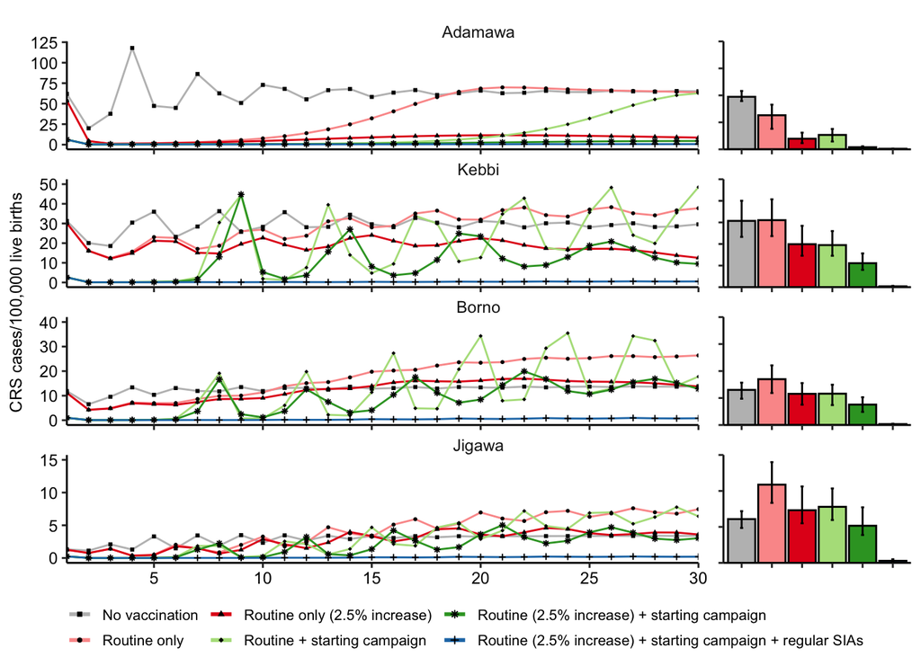

```r
# organise simulation data
combined_crs_incidence_list <- purrr::map(1:length(advanced_scenarios_sia1_medR0_crs_incidence_list),
                                          function(x) rbind(advanced_scenarios_sia1_medR0_crs_incidence_list[[x]],
                                                            advanced_scenarios_sia2_medR0_crs_incidence_list[[x]]))
combined_crs_incidence_list <- purrr::map(1:length(combined_crs_incidence_list),
                                          function(x) rbind(combined_crs_incidence_list[[x]],
                                                            mutate(basic_scenarios_medR0_crs_incidence_list[[x]],
                                                                   sia="sia0")))
names(combined_crs_incidence_list) <- names(advanced_scenarios_sia1_medR0_crs_incidence_list)
scenarios <- data.frame(sia=c("sia0", "sia0", "sia0", "sia2", "sia2", "sia1"),
                        scenario=c("baseline", "0", "0.025", "0", "0.025", "0.025"))
modified_simple_dynamics_crs_burden_dist <- simple_dynamic_crs_burden_dist %>%
  transmute(state=state, crs_burden=crs_burden, sia="sia0", scenario=scenario, sim=sim)
all_crs_burden_dist <- do.call(rbind, list(modified_simple_dynamics_crs_burden_dist,
                                           advanced_dynamic_sia1_crs_burden_dist,
                                           advanced_dynamic_sia2_crs_burden_dist,
                                           transmute(baseline_crs_burden_dist,
                                                     state=state, crs_burden=crs_burden, sia="sia0", scenario="baseline", sim=sim)))

# plot for selected states
p <- combined_yearly_crs_dynamics(these_states=c("Adamawa", "Kebbi", "Borno", "Jigawa"),
                                  crs_incidence_list=combined_crs_incidence_list,
                                  births_list=births_list,
                                  crs_burden_dist=all_crs_burden_dist,
                                  scenarios=scenarios,
                                  file_name="advanced_combined_yearly_crs_incidence_timeseries_pub.pdf",
                                  scale_factor=0.45)
print(p)
```

```r
# plot for all states
states <- c(unique(pull(ng2_pop, state)), "Nigeria")
plots_per_page <- 10
groupings <- split(seq_along(states), ceiling(seq_along(states)/plots_per_page))
scale_factors <- unlist(lapply(groupings, length))/plots_per_page*0.9
scale_factors[length(groupings)] <- scale_factors[length(groupings)] + 0.075
for (ii in seq_along(groupings)) {
  p <- combined_yearly_crs_dynamics(these_states=states[groupings[[ii]]],
                                    crs_incidence_list=combined_crs_incidence_list,
                                    births_list=births_list,
                                    crs_burden_dist=all_crs_burden_dist,
                                    scenarios=scenarios,
                                    file_name=paste0("advanced_combined_yearly_crs_incidence_timeseries_group", ii, ".pdf"),
                                    scale_factor=scale_factors[ii],
                                    legend=(ii==length(groupings)))
}
```

### Change in 30-year CRS burden

Let’s compare the 30-year CRS burden under each scenario in each state to the no RCV introduction conditions.

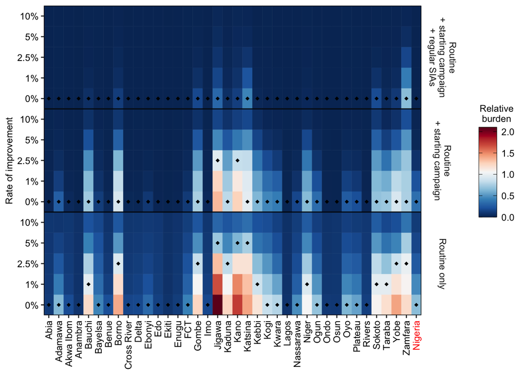

```r
plot_complete_mean_crs_burden_change_heatmap <- function(crs_burden_dist, sia_types, scenarios, file_name) {
  baseline_crs_burden_dist <- crs_burden_dist %>%
    filter(sia=="sia0", scenario=="baseline") %>%
    transmute(state=state, sim=sim, baseline_crs_burden=crs_burden)
  crs_burden_summary <- crs_burden_dist %>%
    filter(!(sia=="sia0" & scenario=="baseline")) %>%
    left_join(baseline_crs_burden_dist, by=c("state", "sim")) %>%
    mutate(change_crs_burden=crs_burden-baseline_crs_burden) %>%
    group_by(state, sia, scenario) %>%
    summarise(mean_percent_change_crs_burden=mean(change_crs_burden/baseline_crs_burden)*100,
              mean_relative_burden=mean(crs_burden/baseline_crs_burden), .groups="keep") %>%
    mutate(scenario=factor(scenario, levels=scenarios),
           sia=factor(sia, sia_types)) %>%
    mutate(state=ifelse(state=="Federal Capital Territory", "FCT", state)) %>%
    ungroup() %>% group_by(state, sia) %>%
    arrange(-desc(state), -desc(sia), -desc(scenario)) %>%
    mutate(is_min_scenario=(scenario==scenario[min(which(mean_relative_burden<1))]))
  state_order <- sort(unique(pull(crs_burden_summary, state)))
  state_order <- c(state_order[which(state_order!="Nigeria")], "Nigeria")
  crs_burden_summary %<>% mutate(state=factor(state, levels=state_order))

  axis_text_colors <- c(rep("black", length(state_order)-1), "red")
  strip_labels <- c("Routine\n+ starting campaign\n+ regular SIAs",
                    "Routine\n+ starting campaign",
                    "Routine only")
  names(strip_labels) <- sia_types
  mean_crs_burden_change_heatmap <- ggplot() +
    geom_tile(data=crs_burden_summary,
              mapping=aes(x=state, y=scenario, fill=mean_relative_burden, color=mean_relative_burden)) +
    geom_point(data=filter(crs_burden_summary, is_min_scenario),
               mapping=aes(x=state, y=scenario), shape=18) +
    scale_fill_gradientn(colours=rev(brewer.pal(11, "RdBu")), breaks=seq(0, 2, 0.5),
                         limits=c(0, 2.1), name="Relative\nburden") +
    scale_color_gradientn(colours=rev(brewer.pal(11, "RdBu")), breaks=seq(0, 2, 0.5),
                          limits=c(0, 2.1), guide="none") +
    labs(y="Rate of improvement", fill="Relative\nburden") +
    scale_y_discrete(labels=paste0(round(scenarios*100, 1), "%"), expand=c(0, 0)) +
    scale_x_discrete(drop=FALSE, expand=c(0, 0)) +
    guides(fill=guide_colorbar(title.position="top", title.hjust=0.5,
                               ticks.colour="black", frame.colour="black")) +
    theme(axis.text.x=element_text(angle=90, size=9, hjust=1, vjust=0.5, color=axis_text_colors), axis.text=element_text(size=9, color="black"),
          axis.title.x=element_blank(),
          axis.title.y=element_text(size=9, color="black"),
          legend.position="right", legend.text=element_text(size=9, color="black"), legend.title=element_text(size=9, color="black")) +
    theme(strip.background=element_blank(), panel.spacing.y = unit(0, "lines"), strip.placement="outside") +
    theme(panel.background=element_blank(), panel.grid=element_blank(), panel.border=element_rect(color="black", fill=NA)) +
    facet_grid(rows=vars(sia), labeller=labeller(sia=strip_labels))

  scale_factor <- 0.5
  pdf(file=file.path(FIGURES_FOLDER, file_name), w=8, h=11*scale_factor)
  print(mean_crs_burden_change_heatmap)
  a <- dev.off()
  return(mean_crs_burden_change_heatmap)
}
complete_mean_crs_burden_change_heatmap <- plot_complete_mean_crs_burden_change_heatmap(crs_burden_dist=all_crs_burden_dist,
                                                                                        sia_types=c("sia1", "sia2", "sia0"),
                                                                                        scenarios=c(0, 0.01, 0.025, 0.05, 0.1),
                                                                                        file_name="complete_mean_crs_burden_change_heatmap.pdf")
complete_mean_crs_burden_change_heatmap
```